# 05-lymphoid-characterization.Rmd

# Gene set enrichment analysis

## AUCell scoring on MSigDB Hallmark Gene sets

```r
# msigdb hallmark
msigdb_hallmark <- msigdbr::msigdbr(species = "Mus musculus", category = "H") %>%
  dplyr::select(gs_name, gene_symbol) %>%
  dplyr::group_by(gs_name) %>%
  dplyr::summarise(genes = list(gene_symbol)) %>%
  deframe()

# c5 onology
msigdb_c5 <- msigdbr::msigdbr(species = "Mus musculus", category = "C5", subcategory = "BP") %>%
  dplyr::select(gs_name, gene_symbol) %>%
  dplyr::group_by(gs_name) %>%
  dplyr::summarise(genes = list(gene_symbol)) %>%
  deframe()

# c7 immune
msigdb_c7 <- msigdbr::msigdbr(species = "Mus musculus", category = "C7") %>%
  dplyr::select(gs_name, gene_symbol) %>%
  dplyr::group_by(gs_name) %>%
  dplyr::summarise(genes = list(gene_symbol)) %>%
  deframe()
```

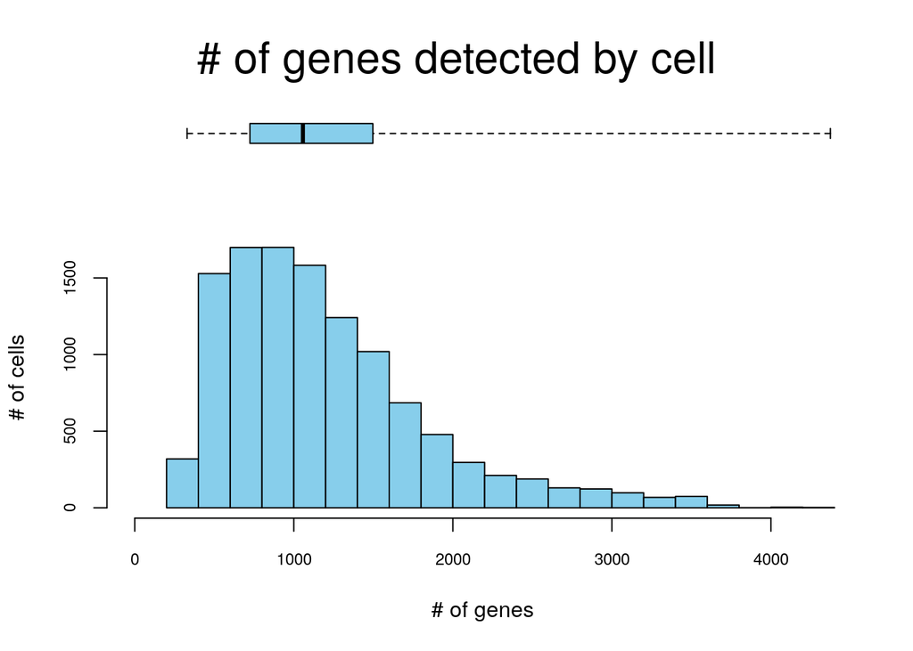

```
##  min   1%   5%  10%  50% 100%
##  329  373  435  510 1057 4374
```

```r
# AUCell on hallmark genesets
cells_rankings <- AUCell_buildRankings(GetAssayData(lymphoid_obj, assay = "RNA", slot = "data"), nCores = 4, plotStats = TRUE)
```

```r
hallmark_AUC <- AUCell_calcAUC(msigdb_hallmark, cells_rankings)
```

## Subtype vs pathway heatmap of AUCell scores

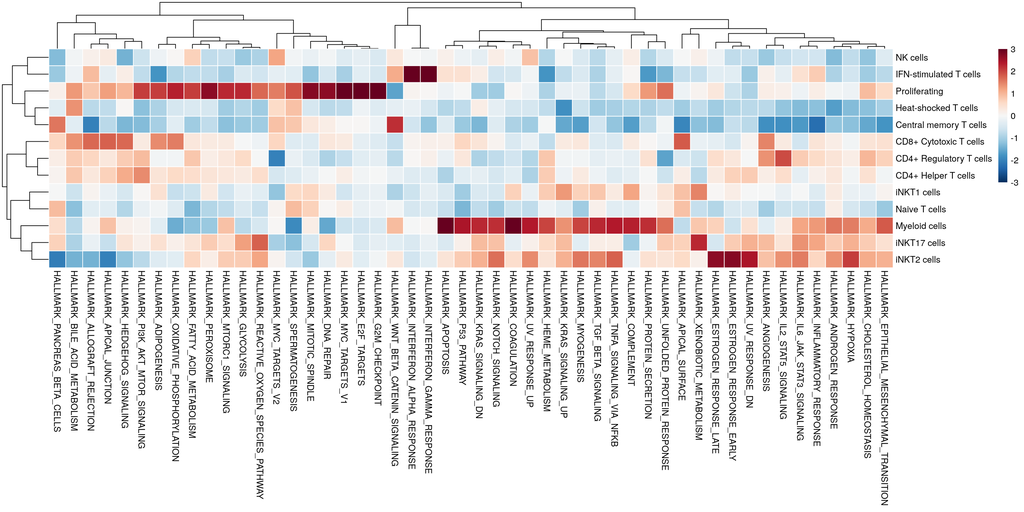

```r
# z scores of AUCell scores across clusters per gene set
hallmark_scores_df <- as.data.frame(t(getAUC(hallmark_AUC)))
hallmark_scores_df$cluster = lymphoid_obj$tcell_subtype

avg_hallmark_scores <- hallmark_scores_df %>%
  group_by(cluster) %>%
  summarise(across(starts_with("HALLMARK"), mean)) %>%
  column_to_rownames("cluster")

hallmark_z_scores <- scale(avg_hallmark_scores)


# Color scale
colors <- rev(RColorBrewer::brewer.pal(n = 11, name = "RdBu"))
colors.use <- grDevices::colorRampPalette(colors = colors)(100)
breaks <- seq(-3, 3, length.out = 101)

pdf(file = file.path(plot_dir, "tcell_subtype_hallmark_auc_heatmap.pdf"), width = 16, height = 8)
pheatmap::pheatmap(mat = hallmark_z_scores,
                   color = colors.use,
                   border_color = "white",
                   breaks = breaks,
                   clustering_distance_rows = "correlation",
                  clustering_distance_cols = "correlation")
```

```r
dev.off()
```

## GSEA analysis of Hallmark gene sets

```r
# get foldchanges for each gene per cluster
clusters <- levels(lymphoid_obj$tcell_subtype)
fc_list <- lapply(clusters, function(cl){
  df <- FoldChange(
    object = lymphoid_obj,
    group.by = "tcell_subtype",
    ident.1 = cl,
    ident.2 = NULL,
    assay = "RNA",
    slot = "data"
  )
  df <- as.data.frame(df)
  df$gene <- rownames(df)

  # Filter by pct.1
  df <- df %>% filter(pct.1 >= 0.05)

  df$cluster <- cl
  df
})
names(fc_list) <- clusters

# rank genes by product of log FCs and -log10 p values
make_rank_vector <- function(df) {
  stat <- df$avg_log2FC
  names(stat) <- df$gene
  stat[is.finite(stat)]
}

fgsea_list_hallmark <- map(fc_list, function(df_cluster) {
  stats_vec <- make_rank_vector(df_cluster)
  print(length(stats_vec))

  fgsea(
    pathways = msigdb_hallmark,
    stats    = stats_vec,
    minSize  = 15,
    maxSize  = 500,
  )
})
```

```
## [1] 4870
## [1] 6651
## [1] 5608
## [1] 6089
## [1] 5765
## [1] 7767
```

```
## [1] 5062
## [1] 5540
## [1] 5524
## [1] 4952
## [1] 5141
## [1] 5878
## [1] 5149
```

```r
fgsea_res_hallmark <- imap_dfr(fgsea_list_hallmark, ~ mutate(.x, cluster = .y))
fgsea_res_hallmark_sig <- fgsea_res_hallmark %>%
  filter(padj < 0.1 & NES > 0) %>%
  arrange(cluster, desc(NES)) %>%
  select(cluster, pathway, NES, pval, padj)
write.csv(fgsea_res_hallmark_sig, file.path(results_dir, "tcell_subtype_hallmark_gsea_results.csv"), row.names = FALSE)
```

## GSEA on C5 GO gene sets

```r
fgsea_list_c5 <- map(fc_list, function(df_cluster) {
  stats_vec <- make_rank_vector(df_cluster)
  print(length(stats_vec))

  fgsea(
    pathways = msigdb_c5,
    stats    = stats_vec,
    minSize  = 15,
    maxSize  = 500,
  )
})
```

```
## [1] 4870
## [1] 6651
```

```
## [1] 5608
## [1] 6089
## [1] 5765
## [1] 7767
```

```
## [1] 5062
## [1] 5540
## [1] 5524
## [1] 4952
## [1] 5141
## [1] 5878
## [1] 5149
```

```r
fgsea_res_c5 <- imap_dfr(fgsea_list_c5, ~ mutate(.x, cluster = .y))
fgsea_res_c5_sig <- fgsea_res_c5 %>%
  filter(padj < 0.1) %>%
  arrange(cluster, desc(NES)) %>%
  select(cluster, pathway, NES, pval, padj)
write.csv(fgsea_res_c5_sig, file.path(results_dir, "tcell_subtype_c5_gsea_results.csv"), row.names = FALSE)
```

## GSEA on C7 immune gene sets

```r
fgsea_list_c7 <- map(fc_list, function(df_cluster) {
  stats_vec <- make_rank_vector(df_cluster)
  print(length(stats_vec))

  fgsea(
    pathways = msigdb_c7,
    stats    = stats_vec,
    minSize  = 15,
    maxSize  = 500,
  )
})
```

```
## [1] 4870
## [1] 6651
```

```
## [1] 5608
## [1] 6089
## [1] 5765
## [1] 7767
```

```
## [1] 5062
## [1] 5540
## [1] 5524
## [1] 4952
## [1] 5141
```

```
## [1] 5878
## [1] 5149
```

```r
fgsea_res_c7 <- imap_dfr(fgsea_list_c7, ~ mutate(.x, cluster = .y))
fgsea_res_c7_sig <- fgsea_res_c7 %>%
       filter(padj < 0.1) %>%
       arrange(cluster, desc(NES)) %>%
       select(cluster, pathway, NES, pval, padj)
write.csv(fgsea_res_c7_sig, file.path(results_dir, "tcell_subtype_c7_gsea_results.csv"), row.names = FALSE)
```

## Save T cell object

```r
saveRDS(lymphoid_obj, file.path(results_dir, "cart_tcell_subclusters.rds"))
```

# Summary of the T cell subtypes

AI-assisted summerization of the full marker lists for each T cell subtype.

### Heat-shock Activated T cells

- Key markers: Hspa1a, Hspa1b, Dnajb1, Jun, Cd69, Ms4a4b, Rasal3, Btg2
- Recently activated or acutely stressed T cells, often induced by tissue dissociation, tumor microenvironment stress, or strong stimulation. Represents a state, not a stable lineage.
- Literature support:
  - Hauet-Broere et al., Ann. Rheum. Dis. 2006: Heat shock proteins induce T cell regulation of chronic inflammation
  - Calderwood & Gong, Trends Biochem. Sci. 2016: Heat Shock Proteins Promote Cancer: It’s a Protection Racket

### CD4+ Regulatory T cells

- Key markers: Foxp3, Ctla4, Il2ra (CD25), Ikzf2, Tnfrsf4
- Immunosuppressive CD4+ T cells involved in immune tolerance and checkpoint regulation. Likely dampen effector responses within the tissue
- Literature support:
  - Rudensky, Immunol. Rev. 2011: Regulatory T Cells and Foxp3
  - Walker, J. Autoimmun. 2013: Treg and CTLA-4: Two intertwining pathways to immune tolerance
  - Chen et al., Int. Immunopharmacol. 2016: CD4⁺CD25⁺ regulatory T cells in tumor immunity

### CD8+ Cytotoxic T cells

- Key markers: Cd8a, Cd8b1, Gzmb, Nkg7, Prf1, Pdcd1
- Activated cytotoxic effector T cells with killing capacity. PD-1 expression suggests recent activation and/or early exhaustion.
- Literature support:
  - Raskov et al., Br. J. Cancer. 2021: Cytotoxic CD8⁺ T cells in cancer and cancer immunotherapy

### CD4+ Helper T cells

- Key markers: Cd4, Icos, Tnfrsf4 (OX40), Bhlhe40
- Activated helper T cells supporting immune coordination and cytokine signaling. Less cytotoxic, more regulatory/organizing in function.
- Literature support:
  - Luckheeram et al., Clin. Dev. Immunol. 2012: CD4⁺ T Cells: Differentiation and Functions

- Key markers: Egr1, Jun, Fos, Atf3, Zfp36, Dusp1, Hspa1a/b, Klf2
- “Shock response” T cells—very typical after stimulation or tissue dissociation
- Literature support:
  - Malissen & Bongrand, Annu. Rev. Immunol. 2015: Early T cell activation: integrating biochemical, structural, and biophysical cues
  - Chen et al., Blood. 2009: Identification of early growth response protein 1 (EGR-1) as a novel target for JUN-induced apoptosis in multiple myeloma

## Proliferating

- Key markers: Mki67, Cdk1, Ccnb1, Ccnb2, Top2a
- Actively cycling lymphocytes. Identity is secondary; represents a cell-cycle state shared across multiple T/NKT subsets.

# iNKT1 cells

- Key markers: Eomes, Tbx21, Prf1, Gzma, Nkg7
- Cytotoxic, Th1-like invariant NKT cells. Specialized for IFN-γ production and effector responses against tumors or infections.
- Literature support:
  - Daussy et al., J. Exp. Med. 2014: T-bet and Eomes instruct the development of two distinct natural killer cell lineages in the liver and in the bone marrow
  - Shimizu et al., Commun. Biol. 2019: Eomes transcription factor is required for the development and differentiation of invariant NKT cells

# NK cells

- Key markers: Ncr1, Klrb1c, Klrd1, Tyrobp, Fcgr3
- Innate cytotoxic lymphocytes lacking TCR signaling. Functionally distinct from T and iNKT cells, with strong NK receptor programs.
- Literature support:
  - Chen et al., Signal Transduction and Targeted Therapy. 2024: Comprehensive snapshots of natural killer cells functions, signaling, molecular mechanisms and clinical utilization

# Naive T cells

# Central memory T cells

- Key markers: Sell (CD62L), S1pr1, Lef1, Foxp1
- Recirculating memory T cells with lymphoid-homing capacity. Less cytotoxic, optimized for long-term immune surveillance.
- Literature support:
  - Yang et al., PLoS One. 2011: The shedding of CD62L (L-selectin) regulates the acquisition of lytic activity in human tumor-reactive T lymphocytes
  - Sallusto et al., Nat. Rev. Immunol. 2004: Central memory and effector memory T cell subsets: function, generation, and maintenance

# IFN-stimulated T cells

- Key markers: Ifit3, Isg15, Oas3, Zbp1
- T cells responding to type I interferon signaling. Reflects cytokine exposure or viral/inflammatory sensing rather than lineage differences.
- Literature support:
  - Crouse et al., Nat. Rev. Immunol. 2015: Regulation of antiviral T cell responses by type I interferons
  - Lim et al., iScience. 2024: Type I interferon signaling regulates myeloid and T cell crosstalk in the glioblastoma tumor microenvironment

# iNKT17 cells

- Key markers: Rorc, Il23r, Il1r1, Cxcr6, Zbtb16
- Pro-inflammatory invariant NKT subset associated with IL-17 biology and tissue residency, particularly in barrier or inflamed tissues.
- Literature support:
  - Giannou et al., Immunity. 2023: Tissue resident iNKT17 cells facilitate cancer cell extravasation in liver metastasis via interleukin-22
  - Thapa et al., Sci. Rep. 2017: The differentiation of ROR-γt expressing iNKT17 cells is orchestrated by Runx1

# iNKT2 cells

- Key markers: Gata3, Il17rb, Il1rl1 (ST2), Areg
- Th2-like invariant NKT cells involved in cytokine support and tissue repair. Amphiregulin suggests regenerative or homeostatic roles.
- Literature support:
  - Krovi & Gapin, Front. Immunol. 2018: Invariant Natural Killer T Cell Subsets—More Than Just Developmental Intermediates